# Project 1: Wrangling, Exploration, Visualization

SDS322E

## Data Wrangling, Exploration, Visualization

### Jacob Risch, jwr2595

#### Introduction

```r
library(tidyverse)
library(kableExtra)
library(knitr)
## install.packages('xlsx',repos =
## 'http://cran.us.r-project.org')
library(xlsx)
manufacturing <- read.xlsx("~/project1/Manufacturing_Stats_by_State.xlsx",
    sheetIndex = 1)

homeless_big <- lapply(1:10, function(i) {
    read.xlsx("~/project1/Homelessness.xlsx", sheetIndex = i)
})
```

I will be looking at data on the homeless population and manufacturing employment. They share a “Year” variable as well as a state variable (sort of: the data will be wrangled so that they have a matching variable). I Think comparing these datasets is interesting because it could highlight the correlation between the presence of manufacturing jobs and homelessness.

#### Tidying: Reshaping

```r
## I will be looking at the data across states and years
## (2014-2015), so will need to 1.) Combine the first two
## datasets in homeless.xlsx, which contain the data for years
## 2014 and 2015.
homeless_2015 <- homeless_big[1] %>% as.data.frame
homeless_2014 <- homeless_big[2] %>% as.data.frame
homeless <- homeless_2015 %>% inner_join(homeless_2014, by = "CoC.Number")
homeless <- homeless %>% select(-"CoC.Name.y")
# 2.) Pivot longer the homeless data so that the years and
# Population type are in their own column. Also, get rid of
# the rows where the 'Year' value isn't a year.
homeless <- homeless %>% pivot_longer(cols = 3:65, names_to = "Population_Type",
    values_to = "Population")
homeless <- homeless %>% separate(col = "Population_Type", sep = "\\.\\.",
    into = c("Population_Type", "Year"))
homeless <- homeless %>% filter(Year %in% c(2014, 2015))

# 3.) I ultimately want to merge my datasets by state and
# year, so I want to combine all observations that take place
# in the same state. County and subdistricts are irrelevant
# to me. I will also

homeless_tidy <- homeless %>% separate(col = "CoC.Number", sep = "-",
    into = c("State_Abbrev.", NA)) %>% mutate_at("Year", as.numeric) %>%
    group_by(State_Abbrev., Population_Type, Year) %>% summarize(Homeless_Population = sum(Population))

# 4.) I now want to change the state names in my
# manufacturing dataframe into their respective abbreviations
# so that I'll be able to merge my homeless_tidy and the
# resulting manufacturing_tidy dataframes.
manufacturing <- manufacturing %>% rename(State_Abbrev. = Geographic.area.name)
manufacturing <- manufacturing %>% mutate(State_Abbrev. = state.abb[match(State_Abbrev.,
    state.name)]) %>% na.omit

# 5.) I want to remove the statistics data from manufacturing
# and filter out observations with confusing values (e.g.
# there is a letter where I'd expect a number).
manufacturing <- manufacturing %>% select(c(1:5, (seq(7, 21,
    2)))) %>% mutate_at(5:13, as.numeric) %>% na.omit


# 6.) Now, since the individual type of manufacturing is not
# important to me, I want to combine the observations by
# state and year for number of workers.
manufacturing_tidy <- manufacturing %>% group_by(State_Abbrev.,
    Year) %>% summarize(Num_Workers = sum(Number.of.employees))
```

I have essentially cut down the manufacturing and homelessness data to a state in which they can be easily joined by their “State Abbrev.” and “Year” values.

#### Joining/Merging

```r
manufacturing_tidy %>% dim
```

```
## [1] 100   3
```

```r
homeless_tidy %>% dim
```

```
## [1] 2856    4
```

```r
manufacturing_tidy %>% ungroup() %>% distinct(State_Abbrev.) %>%
    count()
```

```
## # A tibble: 1 x 1
##       n
##   <int>
## 1    50
```

```r
homeless_tidy %>% anti_join(manufacturing_tidy, by = "State_Abbrev.")
```

```
## # A tibble: 306 x 4
## # Groups:   State_Abbrev., Population_Type [180]
##    State_Abbrev. Population_Type                         Year Homeless_Populati…
##    <chr>         <chr>                                  <dbl>              <dbl>
##  1 ""            Children.of.Parenting.Youth             2015              13242
##  2 ""            Chronically.Homeless                    2014              99132
##  3 ""            Chronically.Homeless                    2015              96275
##  4 ""            Chronically.Homeless.Individuals        2014              83989
##  5 ""            Chronically.Homeless.Individuals        2015              83170
##  6 ""            Chronically.Homeless.People.in.Famili…  2014              15143
##  7 ""            Chronically.Homeless.People.in.Famili…  2015              13105
##  8 ""            Homeless.Individuals                    2014             360189
##  9 ""            Homeless.Individuals                    2015             358422
## 10 ""            Homeless.People.in.Families             2014             216261
## # … with 296 more rows
```

```r
homeless_tidy %>% ungroup() %>% distinct(State_Abbrev.) %>% count()
```

```
## # A tibble: 1 x 1
##       n
##   <int>
## 1    56
```

```r
combined_data <- manufacturing_tidy %>% inner_join(homeless_tidy,
    by = c("State_Abbrev.", "Year"))
combined_buffer <- combined_data %>% unite("Homeless_and_Workers",
    c(3, 5), sep = "_") %>% separate_rows("Homeless_and_Workers",
    sep = "_")
combined_buffer[seq(1, 5100, 2), ]$Population_Type = "Workers"
combined_data2 <- combined_buffer %>% distinct
combined_data2 <- combined_data2 %>% rename(Population = Homeless_and_Workers)
combined_data2 <- combined_data2 %>% mutate_at("Population",
    as.numeric)
combined_data2 <- combined_data2 %>% mutate_at("Year", as.factor)
dim(combined_data2)
```

```
## [1] 2650    4
```

#### Wrangling

```r
# What is the ratio of factory workers to homeless in each
# state?
ratioer <- function(x) {
    x/lag(x)
}
combined_data2 %>% group_by(State_Abbrev.) %>% filter(Population_Type ==
    "Total.Homeless" | Population_Type == "Workers") %>% group_by(State_Abbrev.,
    Population_Type) %>% summarize(mean = mean(Population)) %>%
    group_by(State_Abbrev.) %>% summarize_at("mean", ratioer) %>%
    rename(Workers_to_Homeless = mean) %>% na.omit %>% glimpse
```

```
## Rows: 50
## Columns: 2
## Groups: State_Abbrev. [50]
## $ State_Abbrev.       <chr> "AK", "AL", "AR", "AZ", "CA", "CO", "CT", "DE", "…
## $ Workers_to_Homeless <dbl> 128.410963, 68.386121, 114.947031, 28.046197, 2.5…
```

```r
# What state has the highest chronically homeless population?
combined_data2 %>% filter(Population_Type == "Chronically.Homeless" &
    Year == 2015) %>% arrange(desc(Population))
```

```
## # A tibble: 50 x 4
## # Groups:   State_Abbrev. [50]
##    State_Abbrev. Year  Population Population_Type
##    <chr>         <fct>      <dbl> <chr>
##  1 CA            2015       32174 Chronically.Homeless
##  2 NY            2015        7116 Chronically.Homeless
##  3 FL            2015        6540 Chronically.Homeless
##  4 TX            2015        4304 Chronically.Homeless
##  5 OR            2015        4011 Chronically.Homeless
##  6 MA            2015        2561 Chronically.Homeless
##  7 WA            2015        2482 Chronically.Homeless
##  8 GA            2015        2137 Chronically.Homeless
##  9 IL            2015        1912 Chronically.Homeless
## 10 CO            2015        1877 Chronically.Homeless
## # … with 40 more rows
```

```r
# What was the change in number of workers across 2014 and
# 2015 for each state? What was the change in the number of
# total homeless across 2014 and 2015 for each state? What
# state has the greatest net difference between homelessness
# change and worker change? (Own function defined)
changer <- function(x) {
    x - lag(x)
}
combined_data2 %>% group_by(State_Abbrev., Population_Type) %>%
    filter(Population_Type == "Total.Homeless" | Population_Type ==
        "Workers") %>% summarize(change = changer(Population)) %>%
    na.omit %>% group_by(State_Abbrev.) %>% mutate(Homeless_Worker_Change_Diff = changer(change)) %>%
    arrange(desc(Homeless_Worker_Change_Diff)) %>% kable(align = "c")
```

| State_Abbrev. | Population_Type | change | Homeless_Worker_Change_Diff |
| --- | --- | --- | --- |
| GA | Workers | 18266 | 20997 |
| NE | Workers | 19292 | 19574 |
| AK | Workers | 19041 | 18869 |
| NJ | Workers | 16788 | 18361 |
| OH | Workers | 16762 | 17403 |
| ME | Workers | 15923 | 16277 |
| VT | Workers | 16235 | 16271 |
| TX | Workers | 11358 | 16175 |
| NM | Workers | 14783 | 14900 |
| OR | Workers | 15484 | 14422 |
| NH | Workers | 11134 | 11065 |
| WA | Workers | 10570 | 9593 |
| HI | Workers | 9330 | 8628 |
| IN | Workers | 8174 | 8282 |
| KY | Workers | 7329 | 7880 |
| OK | Workers | 7255 | 7669 |
| FL | Workers | 1668 | 7310 |
| UT | Workers | 6360 | 6416 |
| SD | Workers | 5495 | 5344 |
| MD | Workers | 5850 | 5316 |
| TN | Workers | 3759 | 4051 |
| NC | Workers | 3219 | 4025 |
| CO | Workers | 3721 | 3796 |
| ND | Workers | 1623 | 1576 |
| VA | Workers | 247 | 266 |
| IL | Workers | -507 | -577 |
| RI | Workers | -2289 | -2210 |
| CA | Workers | -959 | -2239 |
| LA | Workers | -3090 | -2565 |
| MS | Workers | -3562 | -3319 |

[output cut: 70 more lines]

```r
# Summary Statistics (3 functions used after grouping):
combined_data2 %>% group_by(Population_Type) %>% summarize(mean = mean(Population),
    sd = sd(Population), median = median(Population)) %>% arrange(desc(mean))
```

```
## # A tibble: 31 x 4
##    Population_Type                          mean     sd  median
##    <chr>                                   <dbl>  <dbl>   <dbl>
##  1 Workers                               300265. 22100. 299196
##  2 Total.Homeless                         11135. 19748.   5608.
##  3 Sheltered.Homeless                      7750. 12587.   3804.
##  4 Homeless.Individuals                    7017  13727.   3439
##  5 Homeless.People.in.Families             4118.  7724.   1579
##  6 Sheltered.Homeless.Individuals          4056.  5475.   2544.
##  7 Sheltered.Homeless.People.in.Families   3694.  7438.   1506.
##  8 Unsheltered.Homeless                    3385. 10416.    877
##  9 Unsheltered.Homeless.Individuals        2961.  9555.    746.
## 10 Chronically.Homeless                    1874.  4547.    722.
## # … with 21 more rows
```

```r
# Counts of every categorical variable
combined_data2 %>% group_by(Population_Type) %>% count
```

```
## # A tibble: 31 x 2
## # Groups:   Population_Type [31]
##    Population_Type                             n
##    <chr>                                   <int>
##  1 Children.of.Parenting.Youth                50
##  2 Chronically.Homeless                      100
##  3 Chronically.Homeless.Individuals          100
##  4 Chronically.Homeless.People.in.Families   100
##  5 Homeless.Individuals                      100
##  6 Homeless.People.in.Families               100
##  7 Homeless.Veterans                         100
##  8 Parenting.Youth.Age.18.24                  50
##  9 Parenting.Youth.Under.18                   50
## 10 Sheltered.Children.of.Parenting.Youth      50
## # … with 21 more rows
```

```r
combined_data2 %>% group_by(State_Abbrev.) %>% count
```

```
## # A tibble: 50 x 2
## # Groups:   State_Abbrev. [50]
##    State_Abbrev.     n
##    <chr>         <int>
##  1 AK               53
##  2 AL               53
##  3 AR               53
##  4 AZ               53
##  5 CA               53
##  6 CO               53
##  7 CT               53
##  8 DE               53
##  9 FL               53
## 10 GA               53
## # … with 40 more rows
```

```r
combined_data2 %>% group_by(Year) %>% count
```

```
## # A tibble: 2 x 2
## # Groups:   Year [2]
##   Year      n
##   <fct> <int>
## 1 2014   1100
## 2 2015   1550
```

```r
# What was the total change in workers in America between
# 2014 and 2015?
sum((combined_data2 %>% group_by(State_Abbrev., Population_Type) %>%
    filter(Population_Type == "Total.Homeless" | Population_Type ==
        "Workers") %>% summarize(change = changer(Population)) %>%
    na.omit %>% group_by(State_Abbrev.) %>% mutate(Homeless_Worker_Change_Diff = changer(change)) %>%
    arrange(desc(Homeless_Worker_Change_Diff)) %>% filter(Population_Type ==
    "Workers"))$change)
```

```
## [1] 13699
```

```r
# What was the total change in homeless in America between
# 2014 and 2015?
sum((combined_data2 %>% group_by(State_Abbrev., Population_Type) %>%
    filter(Population_Type == "Total.Homeless" | Population_Type ==
        "Workers") %>% summarize(change = changer(Population)) %>%
    na.omit %>% group_by(State_Abbrev.) %>% mutate(Homeless_Worker_Change_Diff = changer(change)) %>%
    arrange(desc(Homeless_Worker_Change_Diff)) %>% filter(Population_Type ==
    "Total.Homeless"))$change)
```

```
## [1] -12037
```

```r
# What is the five number summary of the number of workers
# per state?
fivenum(((combined_data2 %>% filter(Population_Type == "Workers"))$Population))
```

```
## [1] 230608.0 285206.0 299196.0 316924.5 356501.0
```

```r
# What is the number of unsheltered homeless parenting youth
# under 18 per state?
combined_data %>% group_by(State_Abbrev.) %>% filter(str_detect(Population_Type,
    "Unsheltered.+18$")) %>% arrange(desc(Homeless_Population))
```

```
## # A tibble: 50 x 5
## # Groups:   State_Abbrev. [50]
##    State_Abbrev.  Year Num_Workers Population_Type             Homeless_Populat…
##    <chr>         <dbl>       <dbl> <chr>                                   <dbl>
##  1 MT             2015      329902 Unsheltered.Parenting.Yout…                 2
##  2 CO             2015      298168 Unsheltered.Parenting.Yout…                 1
##  3 HI             2015      275451 Unsheltered.Parenting.Yout…                 1
##  4 MN             2015      307085 Unsheltered.Parenting.Yout…                 1
##  5 NY             2015      264034 Unsheltered.Parenting.Yout…                 1
##  6 SC             2015      284383 Unsheltered.Parenting.Yout…                 1
##  7 WA             2015      296709 Unsheltered.Parenting.Yout…                 1
##  8 AK             2015      249649 Unsheltered.Parenting.Yout…                 0
##  9 AL             2015      286682 Unsheltered.Parenting.Yout…                 0
## 10 AR             2015      306036 Unsheltered.Parenting.Yout…                 0
## # … with 40 more rows
```

I have found that Indiana has the highest proportion of factory workers to homeless. California has the highest chronically homeless population at 32174, while Delaware has the lowest, at only 80. Georgia had the highest net movement towards factory workers, with 2731 less homeless and 18266 more factory workers between 2014 and 2015. I found that the total mean homeless population in America is 11134 homeless, and that the median number of factory workers is 299196. Interestingly, Montana has the highest number of unsheltered homeless parenting youth under 18, at 2. The most interesting finding here is that it seems, in general, the amount of homelessness dropped from 2014 to 2015, whereas the number of factory workers rose. There must also be some sort of sampling error for unsheltered homeless, as their numbers are near 0 for numerous states.

#### Visualizing

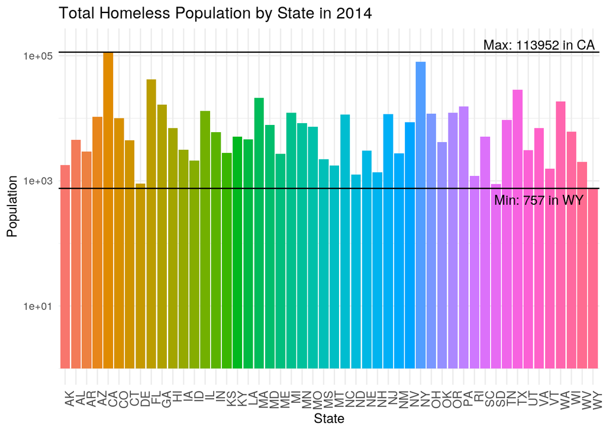

```r
combined_data2 %>% filter(Population_Type == "Total.Homeless",
    Year == 2014) %>% ggplot(aes(x = State_Abbrev., y = Population)) +
    geom_bar(stat = "identity", aes(fill = State_Abbrev.)) +
    scale_y_log10() + labs(title = "Total Homeless Population by State in 2014",
    x = "State", y = "Population") + theme_minimal() + theme(legend.position = "None",
    axis.text.x = element_text(angle = 90, hjust = 1, size = 10)) +
    geom_hline(yintercept = max((combined_data2 %>% filter(Population_Type ==
        "Total.Homeless", Year == 2014))$Population)) + geom_hline(yintercept = min((combined_data2 %>%
    filter(Population_Type == "Total.Homeless", Year == 2014))$Population)) +
    annotate("text", 45, 150000, label = "Max: 113952 in CA") +
    annotate("text", 45, 500, label = "Min: 757 in WY")
```

The plot above visualizes the differences in the total homeless population per state in 2014.

[figure not shown]

```r
maximum = max((combined_data2 %>% filter(Population_Type == "Workers",
    Year == 2015))$Population)
minimum = min((combined_data2 %>% filter(Population_Type == "Workers",
    Year == 2015))$Population)

combined_data2 %>% filter(Population_Type == "Workers", Year ==
    2015) %>% ggplot(aes(x = State_Abbrev., y = Population)) +
    geom_bar(stat = "identity", aes(fill = State_Abbrev.)) +
    labs(title = "Total Factory Worker Population by State in 2015",
        x = "State", y = "Population") + scale_y_log10() + theme_dark() +
    theme(legend.position = "None", axis.text.x = element_text(angle = 90,
        hjust = 1, size = 10)) + geom_hline(yintercept = maximum) +
    geom_hline(yintercept = minimum) + annotate("text", 45, 5e+06,
    label = paste("Max:", as.character(maximum), "in CA")) +
    annotate("text", 45, 500, label = paste("Min:", as.character(minimum),
        "in AK"))
```

This plot visualizes the number of workers in manufacturing per state in 2015.

[figure not shown]

```r
## I will compare the sheltered_homeless observations (x-axis)
## against the number of workers in that respective state
## (y-axis). Color will discern the year.
combined_data2 %>% filter(Population_Type == "Sheltered.Homeless" |
    Population_Type == "Workers") %>% pivot_wider(names_from = ("Population_Type"),
    values_from = ("Population")) %>% ggplot(aes(x = Sheltered.Homeless,
    y = Workers)) + theme_light() + scale_x_log10(name = "Factory Worker Population") +
    scale_y_log10(name = "Sheltered Homeless Population") + annotation_logticks() +
    geom_point(aes(color = Year)) + geom_smooth(method = "lm",
    se = F) + labs(title = "Factory Workers Against Sheltered Homeless Population by State",
    x = "Sheltered Homeless Population", y = "Factory Worker Population")
```

This is a plot comparing the factory worker population in each state to that state’s sheltered homeless population. It appears that the two variables have a slight negative correlation.

#### Concluding Remarks

There are so many interesting variables that I could add to this tidy dataset. I believe a variable describing the longitude and latitude of the capital city of each observation could allow me to further analyze geographical causes of data peculiarities. More variables I could add are: average temperature, per capita GDP, and state income tax rate.